# Barbiero_Lorenzo_rlab05

Barbiero Lorenzo

2023-05-24

```r
library(tidyverse)
library(ggpubr)
library(rjags)
```

## Exercise 1

Define and visualize data

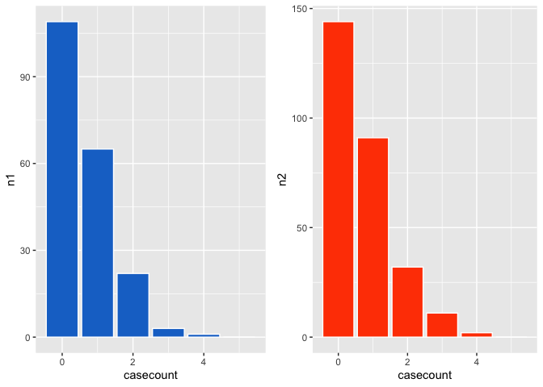

```r
casecount <- seq(0,5)
n1 <- c(109, 65, 22, 3, 1, 0)
n2 <- c(144, 91, 32, 11, 2, 0 )
meas <- data.frame(casecount,n1,n2)
p1 <- ggplot(meas)+geom_bar(aes(casecount,n1), stat = "identity", color="white", fill="dodgerblue3")
p2 <- ggplot(meas)+geom_bar(aes(casecount,n2), stat = "identity", color="white", fill="orangered")

(p <- ggarrange(p1,p2,  nrow=1, ncol=2, heights = c(1,1)))
```

### Flat prior

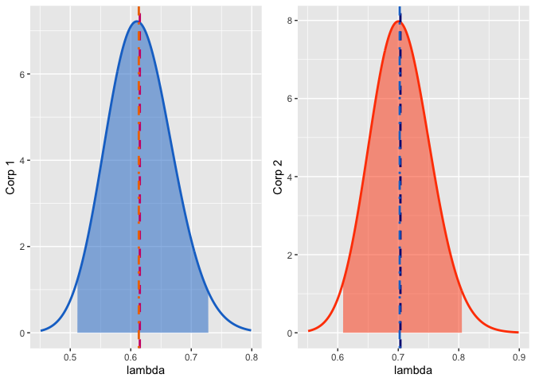

```r
p <- seq(0,1,0.001)
u.n1.post <- dgamma(p,sum(casecount*n1)+1,sum(n1))
u.n1.meanval <- sum(u.n1.post*p*(p[2]-p[1]))
u.n1.var <- sqrt(sum(u.n1.post*p*p*(p[2]-p[1]))-u.n1.meanval**2)
u.n1.q <- c(qgamma(0.025,sum(casecount*n1)+1,sum(n1)),qgamma(0.975,sum(casecount*n1)+1,sum(n1)))

u.n2.post <- dgamma(p,sum(casecount*n2)+1,sum(n2))
u.n2.meanval <- sum(u.n2.post*p*(p[2]-p[1]))
u.n2.var <- sqrt(sum(u.n2.post*p*p*(p[2]-p[1]))-u.n2.meanval**2)
u.n2.q <- c(qgamma(0.025,sum(casecount*n2)+1,sum(n2)),qgamma(0.975,sum(casecount*n2)+1,sum(n2)))

ex1 <- data.frame(p,u.n1.post,u.n2.post)

quantities <- c("mean","median","variance","lower quantile","upper quantile")
corp_1 <- c(u.n1.meanval,qgamma(0.5,sum(casecount*n1)+1,sum(n1)),u.n1.var,u.n1.q[1],u.n1.q[2])
corp_2 <- c(u.n2.meanval,qgamma(0.5,sum(casecount*n2)+1,sum(n2)),u.n2.var,u.n2.q[1],u.n2.q[2])


p1<-ggplot(ex1[ex1$p>0.45&ex1$p<0.8,])+
   geom_line(aes(p,u.n1.post),color="dodgerblue3", lwd=1)+
    geom_area(data=ex1[ex1$p>u.n1.q[1]&ex1$p<u.n1.q[2],], mapping= aes(p,u.n1.post),fill="dodgerblue3",alpha=0.5)+
    geom_vline(xintercept = u.n1.meanval, color="deeppink3",lwd=1,linetype="dashed")+
    geom_vline(xintercept = qgamma(0.5,sum(casecount*n1)+1,sum(n1)), color="darkorange2",lwd=1,linetype="dotdash")+
    labs(x = "lambda", y = "Corp 1")

p2<-ggplot(ex1[ex1$p>0.55&ex1$p<0.9,])+
   geom_line(aes(p,u.n2.post),color="orangered", lwd=1)+
    geom_area(data=ex1[ex1$p>u.n2.q[1]&ex1$p<u.n2.q[2],], aes(p,u.n2.post),fill="orangered",alpha=0.5)+
  geom_vline(xintercept = u.n2.meanval, color="navy",lwd=1,linetype="dashed")+
   geom_vline(xintercept = qgamma(0.5,sum(casecount*n2)+1,sum(n2)), color="dodgerblue3",lwd=1,linetype="dotdash")+
    labs(x = "lambda", y = "Corp 2")


(p <- ggarrange(p1,p2, nrow=1, ncol=2, heights = c(1,1)))
```

```r
(summary <- data.frame(quantities,corp_1,corp_2))
```

```
##       quantities     corp_1     corp_2
## 1           mean 0.61500000 0.70357136
## 2         median 0.61333414 0.70238131
## 3       variance 0.05545269 0.05012766
## 4 lower quantile 0.51112513 0.60874872
## 5 upper quantile 0.72834085 0.80515705
```

### Jeffrey’s Prior

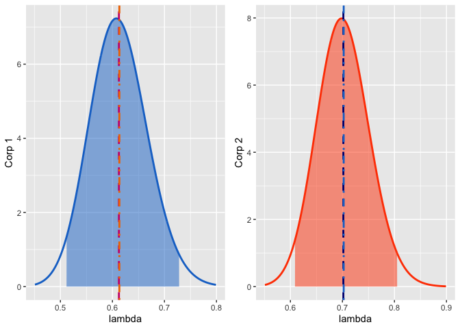

```r
p <- seq(0,1,0.001)
u.n1.post <- dgamma(p,sum(casecount*n1)+0.5,sum(n1))
u.n1.meanval <- sum(u.n1.post*p*(p[2]-p[1]))
u.n1.var <- sqrt(sum(u.n1.post*p*p*(p[2]-p[1]))-u.n1.meanval**2)
u.n1.q <- c(qgamma(0.025,sum(casecount*n1)+1,sum(n1)),qgamma(0.975,sum(casecount*n1)+1,sum(n1)))

u.n2.post <- dgamma(p,sum(casecount*n2)+0.5,sum(n2))
u.n2.meanval <- sum(u.n2.post*p*(p[2]-p[1]))
u.n2.var <- sqrt(sum(u.n2.post*p*p*(p[2]-p[1]))-u.n2.meanval**2)
u.n2.q <- c(qgamma(0.025,sum(casecount*n2)+1,sum(n2)),qgamma(0.975,sum(casecount*n2)+1,sum(n2)))

ex1 <- data.frame(p,u.n1.post,u.n2.post)

quantities <- c("mean","median","variance","lower quantile","upper quantile")
corp_1 <- c(u.n1.meanval,qgamma(0.5,sum(casecount*n1)+1,sum(n1)),u.n1.var,u.n1.q[1],u.n1.q[2])
corp_2 <- c(u.n2.meanval,qgamma(0.5,sum(casecount*n2)+1,sum(n2)),u.n2.var,u.n2.q[1],u.n2.q[2])


p1<-ggplot(ex1[ex1$p>0.45&ex1$p<0.8,])+
   geom_line(aes(p,u.n1.post),color="dodgerblue3", lwd=1)+
    geom_area(data=ex1[ex1$p>u.n1.q[1]&ex1$p<u.n1.q[2],], mapping= aes(p,u.n1.post),fill="dodgerblue3",alpha=0.5)+
    geom_vline(xintercept = u.n1.meanval, color="deeppink3",lwd=1,linetype="dashed")+
    geom_vline(xintercept = qgamma(0.5,sum(casecount*n1)+1,sum(n1)), color="darkorange2",lwd=1,linetype="dotdash")+
    labs(x = "lambda", y = "Corp 1")

p2<-ggplot(ex1[ex1$p>0.55&ex1$p<0.9,])+
   geom_line(aes(p,u.n2.post),color="orangered", lwd=1)+
    geom_area(data=ex1[ex1$p>u.n2.q[1]&ex1$p<u.n2.q[2],], aes(p,u.n2.post),fill="orangered",alpha=0.5)+
  geom_vline(xintercept = u.n2.meanval, color="navy",lwd=1,linetype="dashed")+
   geom_vline(xintercept = qgamma(0.5,sum(casecount*n2)+1,sum(n2)), color="dodgerblue3",lwd=1,linetype="dotdash")+
    labs(x = "lambda", y = "Corp 2")


(p <- ggarrange(p1,p2, nrow=1, ncol=2, heights = c(1,1)))
```

```r
(summary <- data.frame(quantities,corp_1,corp_2))
```

```
##       quantities     corp_1     corp_2
## 1           mean 0.61250000 0.70178566
## 2         median 0.61333414 0.70238131
## 3       variance 0.05533986 0.05006396
## 4 lower quantile 0.51112513 0.60874872
## 5 upper quantile 0.72834085 0.80515705
```

The two priors produce extremely similar results

## Exercise 2

I will perform the following Poissonian MCMC analysis using JAGS. To avoid redundancy I will only analyse the first data set using a uniform prior.

```r
set.seed(28980)
```

Rewrite data

```r
data <- NULL
data$X <- c(rep(0,109),rep(1,65),rep(2,22),rep(3,3),rep(4,1))
```

Make the model in BUGS (ex1.bug)

```
model {
    # data likelihood
    for (i in 1:length(X)) {
        X[i] ~ dpois(p);
    }
    # a uniform prior for p
    p ~ dexp(0.00001); #Jeffrey's prior could be inserted here
    # Predicted data , given p
    Y ~ dpois(p);
}
```

```r
model <- "ex1.bug"
jm <- jags.model(model, data)
update(jm, 1000) # Burn in
```

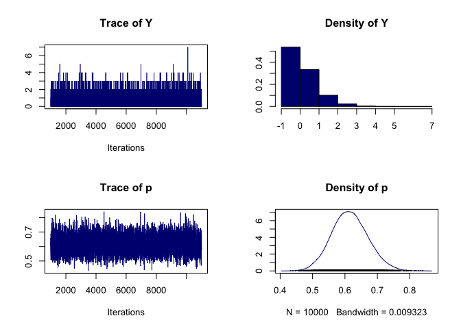

```r
chain <- coda.samples(jm, c("p", "Y"), n.iter=10000)
plot(chain, col="navy")
```

```r
(summary(chain))
```

```
##
## Iterations = 1001:11000
## Thinning interval = 1
## Number of chains = 1
## Sample size per chain = 10000
##
## 1. Empirical mean and standard deviation for each variable,
##    plus standard error of the mean:
##
##     Mean      SD  Naive SE Time-series SE
## Y 0.6211 0.79133 0.0079133      0.0079133
## p 0.6153 0.05549 0.0005549      0.0005549
##
## 2. Quantiles for each variable:
##
##     2.5%    25%    50%    75%  97.5%
## Y 0.0000 0.0000 0.0000 1.0000 3.0000
## p 0.5096 0.5772 0.6134 0.6521 0.7289
```

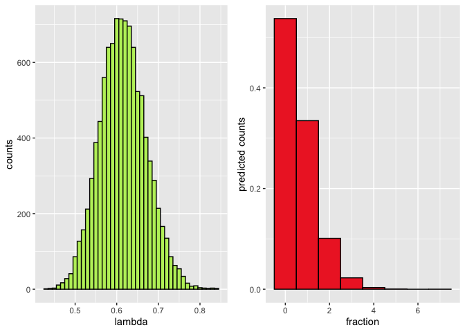

```r
chain.df <- data.frame(as.mcmc(chain))
p1 <- ggplot(chain.df) + geom_histogram(aes(p), binwidth = 0.01, fill = "darkolivegreen2", color="black") + labs(x="lambda",y="counts")
p2 <- ggplot(chain.df) + geom_histogram(aes(Y,after_stat(density)), binwidth = 1, fill = "firebrick2", color="black") + labs(x="fraction",y="predicted counts")
(p <- ggarrange(p1,p2,nrow=1, ncol=2, heights = c(1,1)))
```

#### Results and comparison

comparing the results obtained between the traditional Inference and the JAGS MCMC

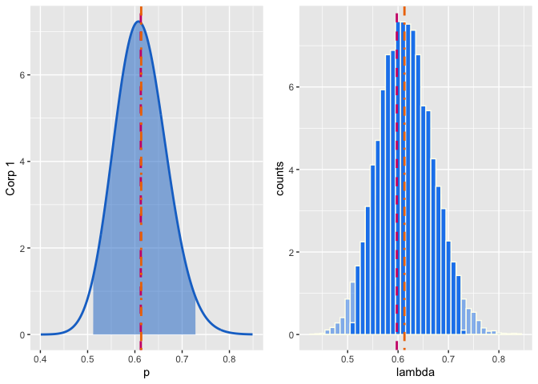

```r
entries <- c("mean","median","variance","upper quantile", "lower quantile")
Standard <- c(u.n1.meanval,qgamma(0.5,sum(casecount*n1)+1,sum(n1)),u.n1.var,u.n1.q[1],u.n1.q[2])
MCMC <- c(0.6139,0.6127,0.0557,0.5088,0.7281)

p1<-ggplot(ex1[ex1$p>0.4 & ex1$p<0.85,])+
   geom_line(aes(p,u.n1.post),color="dodgerblue3", lwd=1)+
    geom_area(data=ex1[ex1$p>u.n1.q[1]&ex1$p<u.n1.q[2],], mapping= aes(p,u.n1.post),fill="dodgerblue3",alpha=0.5)+
    geom_vline(xintercept = u.n1.meanval, color="deeppink3",lwd=1,linetype="dashed")+
    geom_vline(xintercept = qgamma(0.5,sum(casecount*n1)+1,sum(n1)), color="darkorange2",lwd=1,linetype="dotdash")+
    labs(x = "p", y = "Corp 1")

p2 <- ggplot() + geom_histogram(data=chain.df, aes(p, after_stat(density)), binwidth = 0.01, fill = "dodgerblue2", color="ivory", alpha=0.5) + geom_histogram(data=chain.df[chain.df$p > 0.5122 & chain.df$p < 0.7261,], aes(p, after_stat(density)), binwidth = 0.01, fill = "dodgerblue2", color="ivory") + geom_vline(xintercept = 0.5976,color="deeppink3",lwd=1,linetype="dashed") + geom_vline(xintercept = 0.6127, color="darkorange2", lwd=1, linetype="dotdash") + labs(x="lambda",y="counts")

(p <- ggarrange(p1,p2, nrow=1, ncol=2, heights = c(1,1)))
```

```r
(recap <- data.frame(entries,Standard,MCMC))
```

```
##          entries   Standard   MCMC
## 1           mean 0.61250000 0.6139
## 2         median 0.61333414 0.6127
## 3       variance 0.05533986 0.0557
## 4 upper quantile 0.51112513 0.5088
## 5 lower quantile 0.72834085 0.7281
```

Results are really similar

## Exercise 3

### First data collection

For N=116 and y=11 the frequentist estimator is

```r
N=116
y=11
mu <- y/N
varmu <- y*(N-y)/N**2
mu
```

```
## [1] 0.09482759
```

```r
varmu
```

```
## [1] 0.08583532
```

The bayesian estimator is

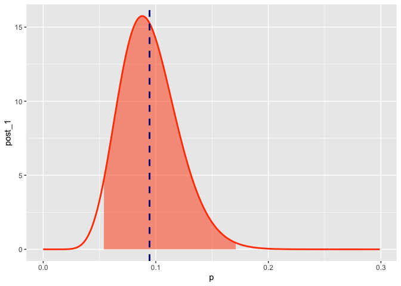

```r
p <- seq(0,1,0.001)
post_1 <- dbeta(p,1+11,10+105)
ex22_1 <- data.frame(p,post_1)
b.mean_1 <- sum(post_1*p*(p[2]-p[1]))
b.var_1 <- sqrt(sum(post_1*p*p*(p[2]-p[1]))-b.mean_1**2)
b.quant_1 <- c(qgamma(0.025,12,115),qgamma(0.975,12,115))

quant <- c("Mean", "Variance", "Upper Quantile", "Lower Quantile")
Posterior <- c(b.mean_1,b.var_1,b.quant_1[1],b.quant_1[2])

(p<-ggplot(ex22_1[ex22_1$p<0.3,])+geom_line(aes(p,post_1), color="orangered", lwd=1)+
    geom_area(data=ex22_1[ex22_1$p>b.quant_1[1]&ex22_1$p<b.quant_1[2],], aes(p,post_1),fill="orangered",alpha=0.5)+
    geom_vline(xintercept = b.mean_1, color="navy",lwd=1,linetype="dashed"))
```

```r
(recap <- data.frame(quant,Posterior))
```

```
##            quant  Posterior
## 1           Mean 0.09448819
## 2       Variance 0.02585418
## 3 Upper Quantile 0.05391804
## 4 Lower Quantile 0.17114816
```

#### Hypothesis test

Frequentist hypothesis test

The distribution for the null hypothesis is a Bernoulli process with p=0.1

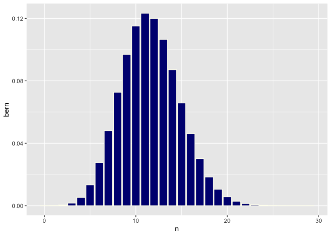

```r
n <- seq(0,116,1)
bern <- dbinom(n,116,0.1)
ex2 <- data.frame(n,bern)

(p<-ggplot(ex2[ex2$n<30,])+geom_bar(aes(n,bern), stat = "identity", color="ivory", fill="navy"))
```

The closest result we can get to a 95%CI is

```r
x1 <- qbinom(0.025,116,0.1)
x2 <- qbinom(0.975,116,0.1)
x1
```

```
## [1] 6
```

```r
x2
```

```
## [1] 18
```

We will check with these boundaries

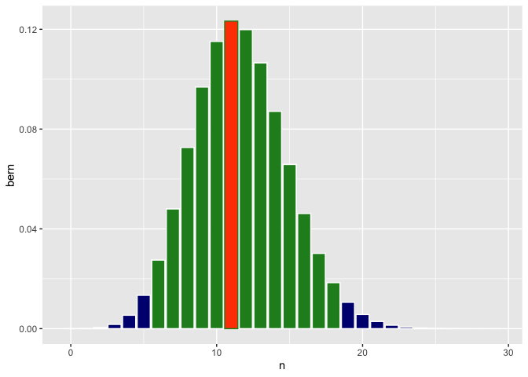

```r
(p<-ggplot(ex2[ex2$n<30,])+geom_bar(aes(n,bern), stat = "identity", color="white", fill="navy") +
    geom_bar(data = ex2[ex2$n>5 & ex2$n<19,], aes(n,bern), stat = "identity", color="white", fill="forestgreen")
  +geom_bar(data = ex2[ex2$n==11,], aes(n,bern), stat = "identity", color="forestgreen", fill="orangered"))
```

Bayesian HT

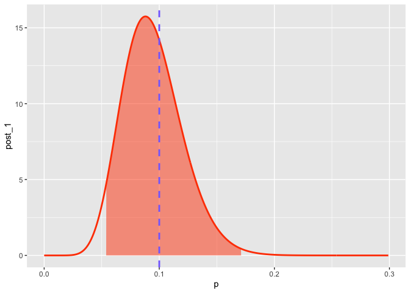

```r
(p<-ggplot(ex22_1[ex22_1$p<0.3,])+geom_line(aes(p,post_1), color="orangered", lwd=1)+
    geom_area(data=ex22_1[ex22_1$p>b.quant_1[1]&ex22_1$p<b.quant_1[2],], aes(p,post_1),fill="orangered",alpha=0.5)+
   geom_vline(xintercept = 0.1, color="lightslateblue",lwd=1,linetype="dashed"))
```

In both cases the null Hypothesis is accepted

### Second data collection

For N=165 and y=9 the frequentist estimator is

```r
N=165
y=9
mu <- y/N
varmu <- y*(N-y)/N**2
mu
```

```
## [1] 0.05454545
```

```r
varmu
```

```
## [1] 0.05157025
```

The Bayesian estimator is:

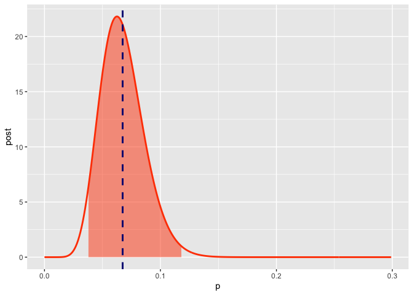

```r
p <- seq(0,1,0.001)
post <- dbeta(p,1+11,10+156)
post2 <- dbeta(p,12+9,115+156)
ex22 <- data.frame(p,post,post2)

b.mean <- sum(post*p*(p[2]-p[1]))
b.var <- sqrt(sum(post*p*p*(p[2]-p[1]))-b.mean**2)
b.quant <- c(qgamma(0.025,12,166),qgamma(0.975,12,166))

b.mean2 <- sum(post2*p*(p[2]-p[1]))
b.var2 <- sqrt(sum(post2*p*p*(p[2]-p[1]))-b.mean2**2)
b.quant2 <- c(qgamma(0.025,12+9,115+156),qgamma(0.975,12+9,115+156))

quant <- c("Mean", "Variance", "Upper Quantile", "Lower Quantile")
Posterior <- c(b.mean,b.var,b.quant[1],b.quant[2])

(p<-ggplot(ex22[ex22$p<0.3,])+geom_line(aes(p,post), color="orangered", lwd=1)+
    geom_area(data=ex22[ex22$p>b.quant[1]&ex22$p<b.quant[2],], aes(p,post),fill="orangered",alpha=0.5)+
    geom_vline(xintercept = b.mean, color="navy",lwd=1,linetype="dashed"))
```

```r
(recap <- data.frame(quant,Posterior))
```

```
##            quant  Posterior
## 1           Mean 0.06741573
## 2       Variance 0.01874123
## 3 Upper Quantile 0.03735286
## 4 Lower Quantile 0.11856650
```

With the previous posterior as prior, so a Beta(12,115)

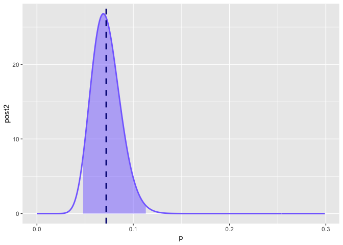

```r
quant <- c("Mean", "Variance", "Upper Quantile", "Lower Quantile")
Posterior <- c(b.mean2,b.var2,b.quant2[1],b.quant2[2])

(p<-ggplot(ex22[ex22$p<0.3,])+geom_line(aes(p,post2), color="lightslateblue", lwd=1)+
    geom_area(data=ex22[ex22$p>b.quant2[1]&ex22$p<b.quant2[2],], aes(p,post2),fill="lightslateblue",alpha=0.5)+
 geom_vline(xintercept = b.mean2, color="navy",lwd=1,linetype="dashed"))
```

```r
(recap <- data.frame(quant,Posterior))
```

```
##            quant  Posterior
## 1           Mean 0.07191781
## 2       Variance 0.01509307
## 3 Upper Quantile 0.04796801
## 4 Lower Quantile 0.11397925
```

#### Hypothesis test

Frequentist hypothesis test

Same procedure as before but with different measurement

```r
n <- seq(0,165,1)
bern <- dbinom(n,165,0.1)
ex2 <- data.frame(n,bern)
x1 <- qbinom(0.025,165,0.1)
x2 <- qbinom(0.975,165,0.1)
x1
```

```
## [1] 9
```

```r
x2
```

```
## [1] 24
```

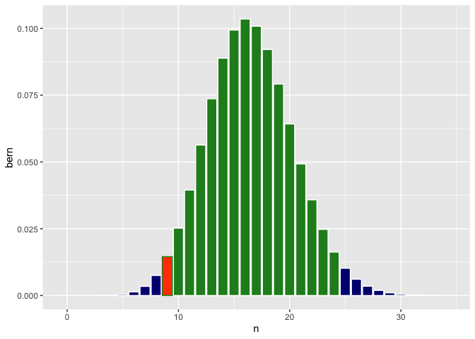

```r
(p<-ggplot(ex2[ex2$n<35,])+geom_bar(aes(n,bern), stat = "identity", color="white", fill="navy") +
    geom_bar(data = ex2[ex2$n>8 & ex2$n<25,], aes(n,bern), stat = "identity", color="white", fill="forestgreen")
  +geom_bar(data = ex2[ex2$n==9,], aes(n,bern), stat = "identity", color="forestgreen", fill="orangered"))
```

Bayesian HT

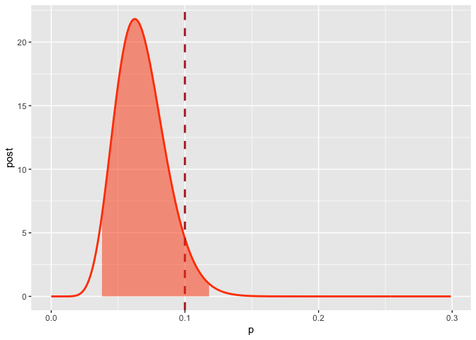

```r
(p<-ggplot(ex22[ex22$p<0.3,])+geom_line(aes(p,post), color="orangered", lwd=1)+
    geom_vline(xintercept = 0.1, color="firebrick",lwd=1,linetype="dashed")+
    geom_area(data=ex22[ex22$p>b.quant[1]&ex22$p<b.quant[2],], aes(p,post),fill="orangered",alpha=0.5))
```

In both cases the null hypothesis is accepted

## Exercise 4

This is a case of Bernoulli MCMC

```r
data2 <- NULL
data2$X <- c(rep(1,11),rep(0,105))
data2$n_next <- 10
```

Define the model with BUGS (ex2.bug)

```
model {
    # data likelihood
    for (i in 1:length(X)) {
        X[i] ~ dbern(p);
    }
    # beta (1,10) prior for p
    p ~ dbeta(1, 10);
    # Predicted data , given p
    y ~ dbin(p, n_next);
}
```

```r
model2 <- "ex2.bug"
jm2 <- jags.model(model2, data2)
update(jm2, 1000)
```

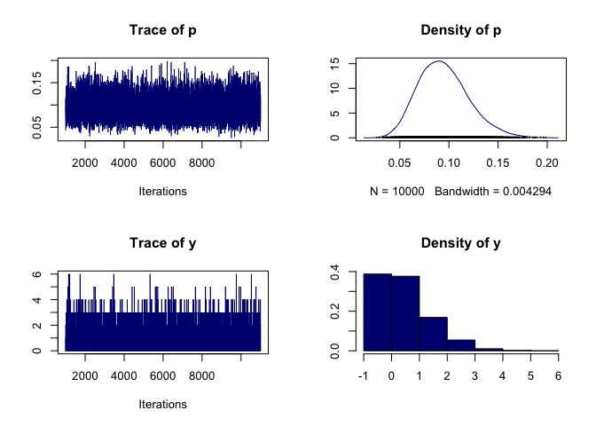

```r
chain2 <- coda.samples(jm2, c("p", "y"), n.iter=10000)
plot(chain2, col="navy")
```

```r
(summary(chain2))
```

```
##
## Iterations = 1001:11000
## Thinning interval = 1
## Number of chains = 1
## Sample size per chain = 10000
##
## 1. Empirical mean and standard deviation for each variable,
##    plus standard error of the mean:
##
##      Mean      SD  Naive SE Time-series SE
## p 0.09463 0.02556 0.0002556      0.0002536
## y 0.93290 0.95535 0.0095535      0.0095535
##
## 2. Quantiles for each variable:
##
##      2.5%     25%     50%    75%  97.5%
## p 0.05104 0.07609 0.09259 0.1106 0.1512
## y 0.00000 0.00000 1.00000 1.0000 3.0000
```

#### Results and comparison

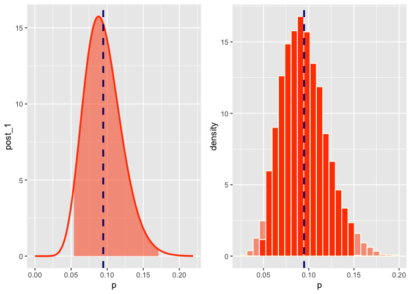

```r
chain2.df <- data.frame( as.mcmc(chain2) )
quant <- c("Mean", "Variance", "Upper Quantile", "Lower Quantile")
Standard <- c(b.mean_1,b.var_1,b.quant_1[1],b.quant_1[2])
MCMC <- c(0.09488,0.02609,0.04978,0.1506)

p1<-ggplot(ex22_1[ex22_1$p<0.22,])+geom_line(aes(p,post_1), color="orangered", lwd=1)+
    geom_area(data=ex22_1[ex22_1$p>b.quant_1[1]&ex22$p<b.quant_1[2],], aes(p,post_1),fill="orangered",alpha=0.5) + geom_vline(xintercept = b.mean_1, color="navy",lwd=1,linetype="dashed")

p2<-ggplot(chain2.df)+geom_histogram(aes(p,after_stat(density)), binwidth=0.007, fill="orangered", color="ivory", alpha=0.5)+geom_histogram(data=chain2.df[chain2.df>0.04978 & chain2.df<0.1506,], aes(p,after_stat(density)), binwidth=0.007, fill="orangered", color="ivory") + geom_vline(xintercept = 0.09488, color="navy",lwd=1,linetype="dashed")

(p <- ggarrange(p1,p2, nrow=1, ncol=2, heights = c(1,1)))
```

```r
(recap <- data.frame(quant,Standard,MCMC))
```

```
##            quant   Standard    MCMC
## 1           Mean 0.09448819 0.09488
## 2       Variance 0.02585418 0.02609
## 3 Upper Quantile 0.05391804 0.04978
## 4 Lower Quantile 0.17114816 0.15060
```